# Part II - (Ford Gobike System Data)

## by (Mahmoud Elsafy)

## Investigation Overview

> In this investigation, I will provide some visuals between some interesting variables to see their impact on other variables such as (Duration of Trips, User Type, Gender of Users, The Age, Trip Time 'Weekday & Day Hours') to answer some of the questions below: 1-What is the peak time of trips during the day hours? 2-What are the range and average of riders ages? 3-What is the percentage for each user type? 4-Which of user type has the long trip duration? 5-Which gender has the longest trips duration during the weekdays? 6-Which is the user type that has the longest duration of trips during the weekdays? 7-What are the highest and lowest average trip duration for each user type and gender?

## Dataset Overview

> This data set includes information about individual rides made in a bike-sharing system covering the greater San Francisco Bay area, The dataset contains 17,3920 rows and 17 columns that repersent the bike riders in San Francisco Bay area with the following importaent vaariables:(Trip Duration (minutes), Start Station (Time,Name) and End Stations (Time,Name),User Type ('Subscriber' = Member , 'Customer' = Casual),Member Birth Year and Age,Member Gender).

> As we see clearly the usage bikes is down in the weekend days (Sat & Sun), and coming rise up in weekdays (working days).

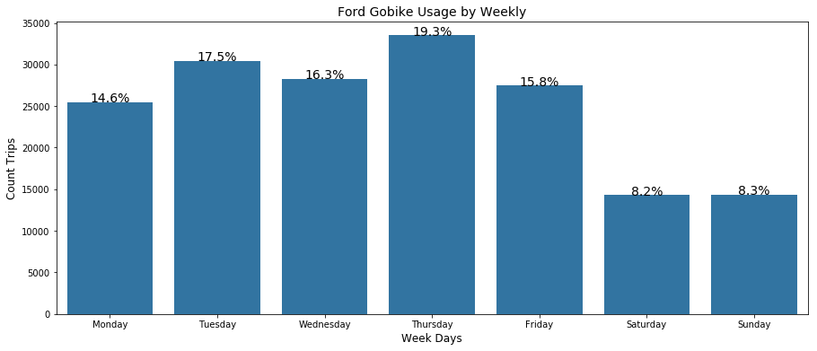

## 2-What are the range and average of riders ages?

> As we see here the range of age is between 21 to 60 age, with outliers between 60 to 70 age, and the most common age is between the bike riders 30 to 42 age, that makes sense.

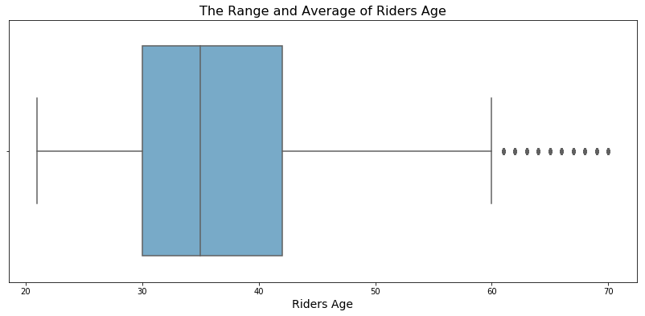

## 3-What is the percentage for each user type?

As we see, most of bike riders are Subscriber 'Member' with (90.5%) and the rest of bike riders are Customer with (9.5%).

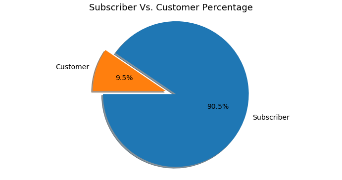

### 4-Which of user type has the long trip duration?

As we see clearly, the Customer bike user spend more time than Subscriber user.

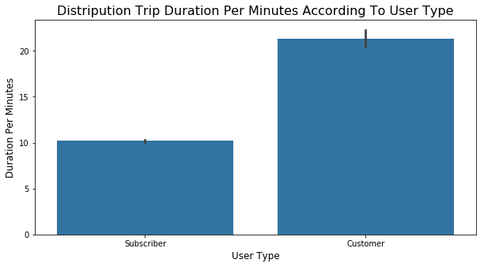

### 5-Which gender has the longest trips duration during the weekdays?

The Other gender in general tend to have much longer trips, especially on the weekend (Sat & Sun) and the second is Female.

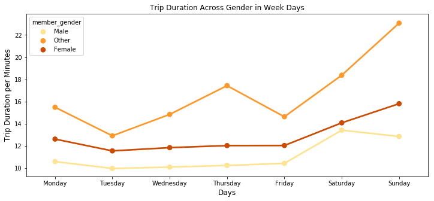

### 6-Which is the user type that has the longest duration of trips during the weekdays?

As we see, The Customer user type tend to have much longer trips, especially on the weekend (Sat & Sun).

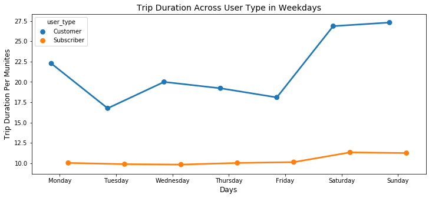

### 7-What are the highest and lowest average trip duration for each user type and gender?

The Other gender (Customer user type) has the highest average (26,286)mins and the lowest for Male gender (Subscriber user type) with (9.776)mins.

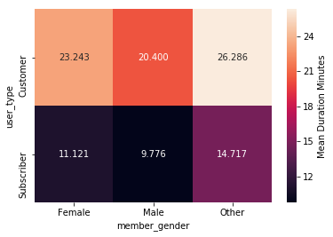